# Super Learner Benchmarks

[Jeremy Coyle](https://github.com/jeremyrcoyle) and [Nima Hejazi](https://nimahejazi.org)

2018-03-23

## Introduction

This document consists of some simple benchmarks for various choices of Super Learner implementation, wrapper functions, and parallelization schemes. The purpose of this document is two-fold:

1. Compare the computational performance of these methods
2. Illustrate the use of these different methods

## Test Setup

### Test Data

```r
n = 1e4
data(cpp_imputed)
cpp_big <- cpp_imputed[sample(nrow(cpp_imputed), n, replace = TRUE), ]
covars <- c("apgar1", "apgar5", "parity", "gagebrth", "mage", "meducyrs",
            "sexn")
outcome <- "haz"

task <- sl3_Task$new(cpp_big, covariates = covars, outcome = outcome,
                     outcome_type = "continuous")
```

- Number of observations: 10000
- Number of covariates: 7

### Test Descriptions

#### Legacy `SuperLearner`

The legacy [SuperLearner](https://github.com/ecpolley/SuperLearner/) package serves as a suitable baseline. We can fit it sequentially (no parallelization):

```r
time_SuperLearner_sequential <- system.time({
  SuperLearner(task$Y, as.data.frame(task$X), newX = NULL, family = gaussian(),
               SL.library = c("SL.glmnet", "SL.randomForest", "SL.speedglm"),
               method = "method.NNLS", id = NULL, verbose = FALSE,
               control = list(), cvControl = list(), obsWeights = NULL,
               env = parent.frame())
})
```

We can also fit it using multicore parallelization, using the `mcSuperLearner` function.

```r
options(mc.cores = cpus_physical)
time_SuperLearner_multicore <- system.time({
  mcSuperLearner(task$Y, as.data.frame(task$X), newX = NULL,
                 family = gaussian(),
                 SL.library = c("SL.glmnet", "SL.randomForest", "SL.speedglm"),
                 method = "method.NNLS", id = NULL, verbose = FALSE,
                 control = list(), cvControl = list(), obsWeights = NULL,
                 env = parent.frame())
})
```

The `SuperLearner` package supports a number of other parallelization schemes, although these weren’t tested here.

#### `sl3` with Legacy `SuperLearner` Wrappers

To maximize comparability with the legacy implementation, we can use `sl3` with the `SuperLearner` wrappers, so that the actual computation used to train the learners is identical:

```r
sl_glmnet <- Lrnr_pkg_SuperLearner$new("SL.glmnet")
sl_random_forest <- Lrnr_pkg_SuperLearner$new("SL.randomForest")
sl_speedglm <- Lrnr_pkg_SuperLearner$new("SL.speedglm")
nnls_lrnr <- Lrnr_nnls$new()

sl3_legacy <- Lrnr_sl$new(list(sl_random_forest, sl_glmnet, sl_speedglm),
                          nnls_lrnr)
```

#### `sl3` with Native Learners

We can also use native `sl3` learners, which have been rewritten to be performant on large sample sizes:

```r
lrnr_glmnet <- Lrnr_glmnet$new()
random_forest <- Lrnr_randomForest$new()
glm_fast <- Lrnr_glm_fast$new()
nnls_lrnr <- Lrnr_nnls$new()

sl3_native <- Lrnr_sl$new(list(random_forest, lrnr_glmnet, glm_fast), nnls_lrnr)
```

#### `sl3` Parallelization Options

`sl3` uses the delayed package to parallelize training tasks. Delayed, in turn, uses the future package to support a range of parallel back-ends. We test several of these, for both the legacy wrappers and native learners.

First, sequential evaluation (no parallelization):

```r
plan(sequential)
test <- delayed_learner_train(sl3_legacy, task)
time_sl3_legacy_sequential <- system.time({
  sched <- Scheduler$new(test, SequentialJob)
  cv_fit <- sched$compute()
})

test <- delayed_learner_train(sl3_native, task)
time_sl3_native_sequential <- system.time({
  sched <- Scheduler$new(test, SequentialJob)
  cv_fit <- sched$compute()
})
```

Next, multicore parallelization:

```r
plan(multicore, workers = cpus_physical)
test <- delayed_learner_train(sl3_legacy, task)
time_sl3_legacy_multicore <- system.time({
  sched <- Scheduler$new(test, FutureJob, nworkers = cpus_physical,
                         verbose = FALSE)
  cv_fit <- sched$compute()
})

test <- delayed_learner_train(sl3_native, task)
time_sl3_native_multicore <- system.time({
  sched <- Scheduler$new(test, FutureJob, nworkers = cpus_physical,
                         verbose = FALSE)
  cv_fit <- sched$compute()
})
```

We also test multicore parallelization with [hyper-threading](https://en.wikipedia.org/wiki/Hyper-threading) – we use a number of workers equal to the number of logical, not physical, cores:

```r
plan(multicore, workers = cpus_logical)
test <- delayed_learner_train(sl3_legacy, task)
time_sl3_legacy_multicore_ht <- system.time({
  sched <- Scheduler$new(test, FutureJob, nworkers = cpus_logical,
                         verbose = FALSE)
  cv_fit <- sched$compute()
})

test <- delayed_learner_train(sl3_native, task)
time_sl3_native_multicore_ht <- system.time({
  sched <- Scheduler$new(test, FutureJob, nworkers = cpus_logical,
                         verbose = FALSE)
  cv_fit <- sched$compute()
})
```

Finally, we test parallelization using multisession:

```r
plan(multisession, workers = cpus_physical)
test <- delayed_learner_train(sl3_legacy, task)
time_sl3_legacy_multisession <- system.time({
  sched <- Scheduler$new(test, FutureJob, nworkers = cpus_physical,
                         verbose = FALSE)
  cv_fit <- sched$compute()
})

test <- delayed_learner_train(sl3_native, task)
time_sl3_native_multisession <- system.time({
  sched <- Scheduler$new(test, FutureJob, nworkers = cpus_physical,
                         verbose = FALSE)
  cv_fit <- sched$compute()
})
```

## Results

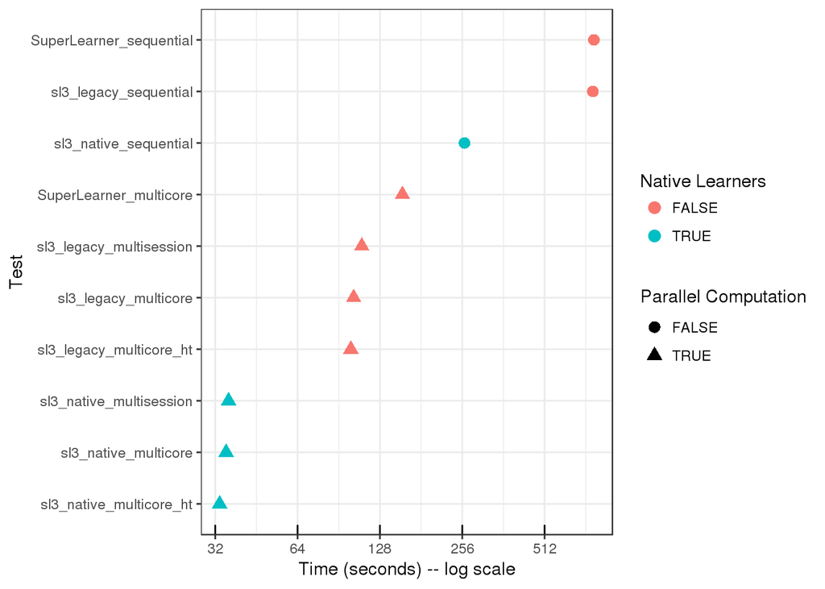

## Session Information

R version 3.4.4 (2018-03-15) Platform: x86_64-pc-linux-gnu (64-bit) Running under: Red Hat Enterprise Linux Server release 6.9 (Santiago)

Matrix products: default BLAS/LAPACK: /usr/lib64/libopenblas-r0.2.20.so

locale: [1] LC_CTYPE=en_US.UTF-8 LC_NUMERIC=C  
[3] LC_TIME=en_US.UTF-8 LC_COLLATE=en_US.UTF-8  
[5] LC_MONETARY=en_US.UTF-8 LC_MESSAGES=en_US.UTF-8  
[7] LC_PAPER=en_US.UTF-8 LC_NAME=C  
[9] LC_ADDRESS=C LC_TELEPHONE=C  
[11] LC_MEASUREMENT=en_US.UTF-8 LC_IDENTIFICATION=C

attached base packages: [1] parallel stats graphics grDevices utils datasets base

other attached packages: [1] speedglm_0.3-2 MASS_7.3-49  
[3] randomForest_4.6-12 glmnet_2.0-13  
[5] foreach_1.4.4 Matrix_1.2-12  
[7] scales_0.5.0.9000 stringr_1.3.0  
[9] data.table_1.10.4-3 ggplot2_2.2.1.9000  
[11] future_1.7.0 SuperLearner_2.0-23-9000 [13] nnls_1.4 delayed_0.2.1  
[15] sl3_1.0.0 knitr_1.20  
[17] nima_0.4.6 fcuk_0.1.21

loaded via a namespace (and not attached): [1] stringdist_0.9.4.7 origami_1.0.0 gtools_3.5.0  
[4] purrr_0.2.4 listenv_0.7.0 lattice_0.20-35  
[7] ggthemes_3.4.0 colorspace_1.3-2 htmltools_0.3.6  
[10] yaml_2.1.18 rlang_0.2.0.9000 pillar_1.2.1  
[13] withr_2.1.1.9000 uuid_0.1-2 ProjectTemplate_0.8 [16] plyr_1.8.4 munsell_0.4.3 gtable_0.2.0  
[19] visNetwork_2.0.3 devtools_1.13.5 htmlwidgets_1.0  
[22] codetools_0.2-15 evaluate_0.10.1 memoise_1.1.0  
[25] rstackdeque_1.1.1 methods_3.4.4 Rcpp_0.12.16  
[28] backports_1.1.2 checkmate_1.8.5 jsonlite_1.5  
[31] abind_1.4-5 gridExtra_2.3 digest_0.6.15  
[34] stringi_1.1.7 BBmisc_1.11 grid_3.4.4  
[37] rprojroot_1.3-2 tools_3.4.4 magrittr_1.5  
[40] lazyeval_0.2.1 tibble_1.4.2 future.apply_0.1.0 [43] pkgconfig_2.0.1 iterators_1.0.9 assertthat_0.2.0  
[46] rmarkdown_1.9 R6_2.2.2 globals_0.11.0  
[49] igraph_1.2.1 compiler_3.4.4